# Unpacking the Invisible: Exploring the Mental Health Challenges of Living Through a Global Pandemic

Carlos van der Ley, Christine Kwon, Connor Bates, Leonardo Gonzalez

## Introduction

Mental health represents a critical aspect of an individual’s overall well being as well as am important branch of Cognitive Science. Understanding not only a single individual’s mental health, but also community’s discussions and perceptions of mental health are essential to providing people with the help and support that they need. One online platform where community members come together to discuss mental and addiction topics is the online forum Reddit. Beginning in late 2018, data was collected from the platforms largest mental health centered communities for nearly two years. Our exploration of mental health discussion will leverage the rich data set provided by the platform in order to explore changes in mental health and addiction discussions in the period leading up to, as well as the beginning of the 2019-2020 pandemic.

Link to the original study (Low et al. (2020b)):  
Low , D., Rumker, L., Talkar, T., Torous, J., Cecchi, G., & Ghosh, S. (2020, October 12). Natural language processing reveals vulnerable mental health support groups and heightened health anxiety on reddit during COVID-19: Observational study. Journal of medical Internet research. Retrieved from https://pubmed.ncbi.nlm.nih.gov/32936777/

This Dataset was created in conjunction with the National Institutes of Health in order to in to gather a more solid understanding of how online mental health support groups were utilized as a coping mechanism during the beginning of the 2019-2020 Pandemic. According to observational analysis conducted by the World Health Organization, the beginning lockdown period of the COVID-19 Pandemic saw an explosion of Anxiety, Depression, and related disorders (WHO, 1). The negative effects of this rapidly growing mental crisis were only compounded by what the World Health Organization describes as a “Gap in Care”. As a result of spiking costs in healthcare, impacted medical facilities due to COVID-19 infection, and isolation as a result of lockdowns drove many people to seek help and community online as a proxy for face-to-face treatment (WHO). This trend is especially pronounced in younger populations who have less access to traditional health care.

In addition to rising rates of mental health disorders, the American Psychological Association noted that substance use disorders grew significantly during the early stages of the Pandemic (Abramson (2021)). The CDC estimates that usage rates for non-prescribed drugs increased 13% in time period of June 2019 to June 2020 (Abramson 2021). This added additional stress to an already fragile healthcare system, and resulted in a spike in overdose related deaths across America in particular, but similar trends were visible world wide.

Given the wealth of data from the Reddit Mental Health data set Team Tiny Models hopes to analyse the use of the Reddit Platform as tool for connecting those with both mental health disorders and substance use disorders over the years leading up to and immediately proceeding the early 2020 lock downs. As a group, we hope to explore the following questions:

## Questions

- 1. How did economic stress change over the Pandemic, and did is it related to changes within emotion (i.e. Anger, Anxiety, General Negative Emotion).
- 2. Do changes within substance use disorder communities mirror trends within mental health communities?
- 3. Do different mental health/emotional states affect the number of words written in a post?

## Data

### Data Introduction

The original data in this analysis is from Reddit and comprises 107 different datasets, including posts from 15 mental health support groups across 28 subreddits from 2018 to 2020. It was originally used, from January to April 2020, to analyze how COVID-19 affected mental health support groups(Low et al. 2020a). The dataset was downloaded from Open Science Framework (OSF)[^1], a free and open-source project management tool for researchers.

**Reddit Mental Health Dataset** Contains posts and text features for the following timeframes from 28 mental health and non-mental health subreddits:

- 15 specific mental health support groups (r/EDAnonymous, r/addiction, r/alcoholism, r/adhd, r/anxiety, r/autism, r/bipolarreddit, r/bpd, r/depression, r/healthanxiety, r/lonely, r/ptsd, r/schizophrenia, r/socialanxiety, and r/suicidewatch)
- 2 broad mental health subreddits (r/mentalhealth, r/COVID19_support)
- 11 non-mental health subr*eddits (r/conspiracy, r/divorce, r/fitness, r/guns, r/jokes, r/legaladvice, r/meditation, r/parenting, r/personalfinance, r/relationships, r/teaching).

Each group has four datasets. For example the adhd group has the following datasets: adhd_2018_features_tfidf256, adhd_2019_features_tfidf256, adhd_post_features_tfidf256, and adhd_pre_features_tfidf256.

- post: Jan 1 to April 20, 2020 (called “mid-pandemic” in manuscript; r/COVID19_support appears). Unique users: 320,364.
- pre: Dec 2018 to Dec 2019. A full year which provides more data for a baseline of Reddit * posts. Unique users: 327,289.
- 2019: Jan 1 to April 20, 2019 (r/EDAnonymous appears). A control for seasonal fluctuations to match post data. Unique users: 282,560.
- 2018: Jan 1 to April 20, 2018. A control for seasonal fluctuations to match post data. Unique users: 177,089

Unique users across all time windows (pre and 2019 overlap): 826,961.

**Variables description:** * subreddit: grupos on Reddit about a topic * author: unique in the same group * year * month * day * post * n_words: number of words in each post * Sent_neg: the probability of the post being negative (calculate by an algorithm) * Sent_neu: the probability of the post being neutral (calculate by an algorithm) * Sent_pos: the probability of the post being positive (calculate by an algorithm)

**Variables that represent mental health issues:** All variables below represent the number or words detected by the **liwc**[^2] scale that represent that specific sentiment. It is a measured through people’s text.

- Isolation_total
- Domestic_stress_total
- Economic_stress_total
- liwc_anger
- liwc_anxiety
- liwc_negative_emotion
- liwc_positive_emotion
- liwc_sadness

Stress scale: Individual scores on the Perceived Stress Scale 14 (PSS) can range from 0 to 56, with higher scores indicating higher perceived stress.

**License** This dataset is made available under the Public Domain Dedication and License v1.0 whose full text can be found at http://www.opendatacommons.org/licenses/pddl/1.0/

### Load packages

```r
library(tidyverse)
library(tidymodels)
library(forcats)
library(olsrr)
library(skimr)
library(viridis)
library(srvyr)
library(scales)
library(osfr) #from osf website
library(zoo)
library(DT)
library(HH)
```

### Data Import

```r
if(!file.exists("data/mental_health_.rda")) {
  cidr <- getwd()
  mkfldr <- "data/"
  dir.create(file.path(cidr, mkfldr), recursive = TRUE)
  osf_retrieve_file("https://osf.io/7peyq/data/input/5efd0743af1156008d3b5532") |>
    osf_download("data/")
}
```

### Data Wrangling

The original data after importing comprises 107 different datasets, with 350 variables each, in a 2.6GB compress file, but only 56 are useful for our analysis. These 56 datasets are related to the following mental health groups with four datasets each: anxiety, socialanxiety, healthanxiety, autism, adhd, ptsd, lonely, depression, suicidewatch, bipolarreddit, bpd, addiction, alcoholism, and schizophrenia.

Steps taken to reshape the data that would be useful for our analysis:

#### Step 1

**Get related mental datasets:** select only datasets related to mental health groups mentioned previously. The code below will check if data already exists, if so, it will skip this step.

```r
if(!file.exists("data/mental_health.rda")) {

  # GET RELATED MENTAL FILES
  mental_files = "anxiety|autism|adhd|ptsd|lonely|depression|suicidewatch|bipolarreddit|bpd|addiction|alcoholism|schizophrenia"

  data <- list.files(recursive = TRUE,
                     path = "data/reddit_mental_health_dataset",
                     pattern = mental_files,
                     full.names = TRUE) |>
    purrr::map(~read_csv(.))
}
```

#### Step 2

**Combine datasets:** after dataset selection, we combine them all, since they have the same structure.

```r
if(!file.exists("data/mental_health.rda")) {

  # COMBINE DATASETS
  red_mh <- data |>
    map_df(bind_rows)

}
```

#### Step 3

**Select important features:** select only the most useful features among 350 originally.

```r
if(!file.exists("data/mental_health.rda")) {

  # SELECT IMPORTANT FEATURES FROM DATASET
features <- c("subreddit", "author",    "date", "post", "n_words", "sent_neg", "sent_neu", "sent_pos", "isolation_total", "economic_stress_total", "domestic_stress_total", "liwc_anger", "liwc_anxiety", "liwc_negative_emotion", "liwc_positive_emotion", "liwc_sadness")

  red_mh <- red_mh |>
    select(all_of(features))
}
```

#### Step 4

**drop duplication:** Because two datasets overlap, **pre**: Dec 2018 to Dec 2019, and **2019**: Jan 1 to April 20, 2019, we will drop duplicate data.

```r
if(!file.exists("data/mental_health.rda")) {

  # DROP DUPLICATE USER
  red_mh <- unique(red_mh)
}
```

#### Step 5

**Split date:** create three new variables for date: year, month, and day, and drop date.

```r
# IF DATA EXISTS IT WILL SKIP THIS STEP
if(!file.exists("data/mental_health.rda")) {

  # SPLIT DATE IN YEAR MONTH AND DAY
  red_mh <- red_mh |>
    separate(date, c("year", "month", "day"), remove = TRUE)

}
```

#### Step 6

**Save dataset and delete raw data:** save the non-wrangled and wrangled datasets into the data folder, and delete 51 unnecessary and unused datasets from 107 total, releasing about 2.5GB on disk.

```r
# IF DATA EXISTS IT WILL SKIP THIS STEP
if(!file.exists("data/mental_health.rda")) {

  # SAVE THE FINAL DATASET
  save(red_mh, file="data/mental_health.rda")

  # DELETE RAW DATA: 107 FILES, +/- 2.5GB
  unlink("data/reddit_mental_health_dataset", recursive = TRUE)
}
```

#### Load the data

```r
# LOAD THE DATASET
load("data/mental_health.rda")
```

## Analysis

### Exploratory Data Analysis

**Summary of the data:** Our data has 390119 rows, and 18 columns, with 6 columns as character, and 12 as numeric. Any missing value detected across variables. The summary of some variables doesn’t see right at first glance; for instance, the subreddit variable has **min 3** and **max 13**, but because they are character, so the summary shows the length of each category under that variable. The mean of the variables thatrepresent mental health issues are significant and we will explore them through the analysis.

```r
skim(red_mh)
```

Data summary

| Name | red_mh |
| --- | --- |
| Number of rows | 390119 |
| Number of columns | 18 |
| _______________________ |  |
| Column type frequency: |  |
| character | 6 |
| numeric | 12 |
| ________________________ |  |
| Group variables | None |

**Variable type: character**

| skim_variable | n_missing | complete_rate | min | max | empty | n_unique | whitespace |
| --- | --- | --- | --- | --- | --- | --- | --- |
| subreddit | 0 | 1 | 3 | 13 | 0 | 14 | 0 |
| author | 0 | 1 | 3 | 20 | 0 | 305514 | 0 |
| year | 0 | 1 | 4 | 4 | 0 | 3 | 0 |
| month | 0 | 1 | 2 | 2 | 0 | 12 | 0 |
| day | 0 | 1 | 2 | 2 | 0 | 31 | 0 |
| post | 0 | 1 | 4 | 40007 | 0 | 380978 | 0 |

**Variable type: numeric**

| skim_variable | n_missing | complete_rate | mean | sd | p0 | p25 | p50 | p75 | p100 | hist |
| --- | --- | --- | --- | --- | --- | --- | --- | --- | --- | --- |
| n_words | 0 | 1 | 184.68 | 185.38 | 1 | 72.00 | 132.00 | 234.00 | 12003 | ▇▁▁▁▁ |
| sent_neg | 0 | 1 | 0.15 | 0.08 | 0 | 0.09 | 0.14 | 0.20 | 1 | ▇▂▁▁▁ |
| sent_neu | 0 | 1 | 0.73 | 0.10 | 0 | 0.68 | 0.74 | 0.80 | 1 | ▁▁▁▇▃ |
| sent_pos | 0 | 1 | 0.12 | 0.07 | 0 | 0.07 | 0.11 | 0.16 | 1 | ▇▁▁▁▁ |
| isolation_total | 0 | 1 | 0.37 | 0.97 | 0 | 0.00 | 0.00 | 0.00 | 37 | ▇▁▁▁▁ |
| economic_stress_total | 0 | 1 | 0.76 | 1.55 | 0 | 0.00 | 0.00 | 1.00 | 64 | ▇▁▁▁▁ |
| domestic_stress_total | 0 | 1 | 0.13 | 0.56 | 0 | 0.00 | 0.00 | 0.00 | 36 | ▇▁▁▁▁ |
| liwc_anger | 0 | 1 | 1.49 | 3.31 | 0 | 0.00 | 1.00 | 2.00 | 1201 | ▇▁▁▁▁ |
| liwc_anxiety | 0 | 1 | 0.94 | 1.58 | 0 | 0.00 | 0.00 | 1.00 | 97 | ▇▁▁▁▁ |
| liwc_negative_emotion | 0 | 1 | 5.06 | 6.05 | 0 | 1.00 | 3.00 | 7.00 | 1201 | ▇▁▁▁▁ |
| liwc_positive_emotion | 0 | 1 | 5.33 | 6.15 | 0 | 1.00 | 4.00 | 7.00 | 160 | ▇▁▁▁▁ |
| liwc_sadness | 0 | 1 | 1.41 | 2.04 | 0 | 0.00 | 1.00 | 2.00 | 121 | ▇▁▁▁▁ |

#### Subreddit groups:

Number os subreddit groups during Dec 2018 to Apr 2020. Here we can see that some groups have a great amount of poster, such as adhd, anxiety, bpd, depression, lonely, socialanxiety, and suicidewatch.

```r
table(red_mh$subreddit)
```

```
##
##     addiction          adhd    alcoholism       anxiety        autism
##          6875         42220          5326         54902          8081
## bipolarreddit           bpd    depression healthanxiety        lonely
##          5359         22490        114841          8094         22043
##          ptsd schizophrenia socialanxiety  suicidewatch
##          7989          7976         20631         63292
```

#### Total number of emotional words:

```r
datatable(red_mh |>
  group_by(year) |>
  summarise(
    total_isolation = sum(isolation_total),
    total_economic_stress = sum(economic_stress_total),
    total_domestic_stress = sum(domestic_stress_total),
    total_anger = sum(liwc_anger),
    total_anxiety = sum(liwc_anxiety),
    total_neg_emotion = sum(liwc_negative_emotion),
    total_pos_emotion = sum(liwc_positive_emotion),
    total_sad_emotion = sum(liwc_sadness)
  ))
```

|  | year | total_isolation | total_economic_stress | total_domestic_stress | total_anger | total_anxiety | total_neg_emotion | total_pos_emotion | total_sad_emotion |
| --- | --- | --- | --- | --- | --- | --- | --- | --- | --- |
| 1 | 2018 | 28688 | 66908 | 10444 | 125536 | 78944 | 430035 | 449996 | 123858 |
| 2 | 2019 | 67961 | 143070 | 24077 | 275555 | 179911 | 937650 | 1001475 | 255770 |
| 3 | 2020 | 49095 | 87259 | 15886 | 180969 | 109482 | 606397 | 629590 | 170445 |

#### Sum of the number of posts’ words across the data:

The graph below show the total number of words in each post by year. It matches with the table information from above. Although they might not be related. It seems that users have been writing more in 2020, proportionally.

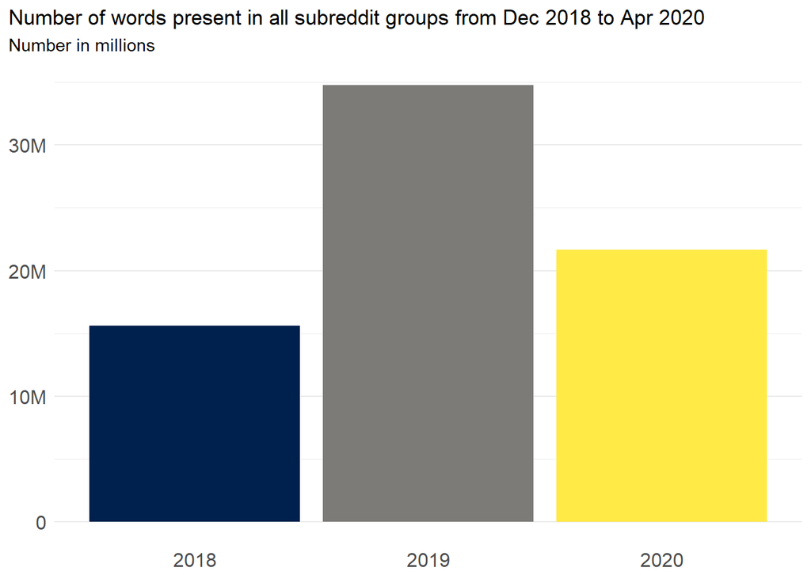

```r
options(scipen = 999)
red_mh |>
  group_by(year) |>
  summarize(total_words = sum(n_words)) |>
  ggplot(aes(y = total_words,
             x = year, fill=year)) +
  geom_bar(stat = "identity",
           # position = "dodge"
           ) +
  scale_fill_viridis(discrete = TRUE, option="cividis") +
  theme_minimal() +
  guides(fill = guide_legend("Flavor")) +
  labs(title = "Number of words present in all subreddit groups from Dec 2018 to Apr 2020",
       subtitle = "Number in millions",
       x = NULL,
       y =NULL) +
  guides(fill = "none") +
  theme(
    plot.title.position = "plot",
    axis.text.x=element_text(size=12),
    axis.text.y=element_text(size=12),
    panel.grid.major.x = element_blank()
  ) +
 scale_y_continuous(labels = scales::label_number_si())
```

The graph below shows the total number of words only for 2019 and 2020 from Jan to Apr, since for 2018 we only have Dec with data. 2020 overpass 2019 slightly

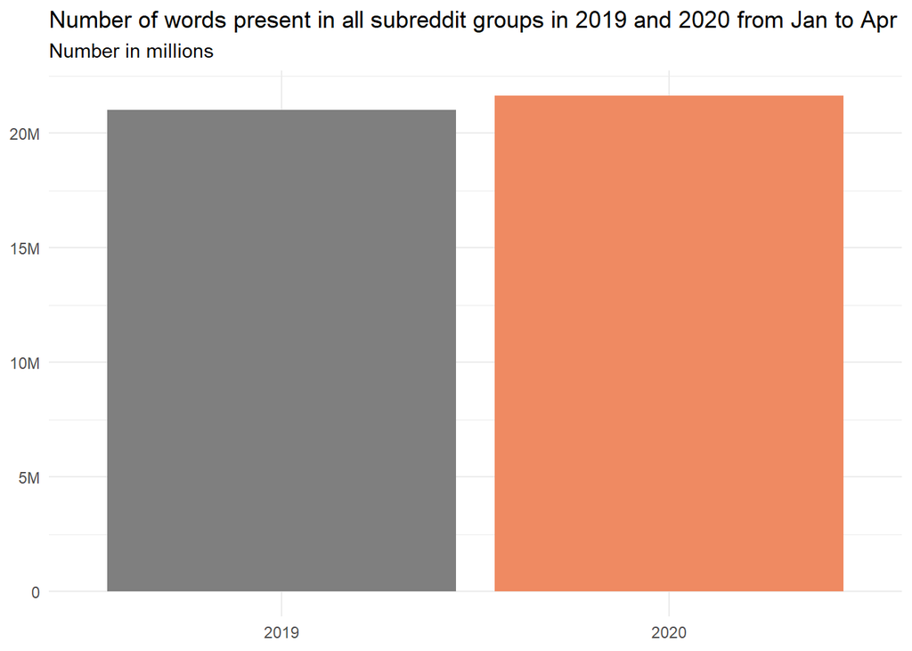

```r
options(scipen = 999)
red_mh |>
  filter(
    month == "01" | month == "02" | month == "03"  | month == "04",
    year == "2019" | year == "2020"
  ) |>
  group_by(year) |>
  summarize(total_words = sum(n_words)) |>
  ggplot(aes(y = total_words,
             x = year, fill = year)) +
  geom_bar(stat = "identity",
           # position = "dodge"
  ) +
  scale_fill_manual(values = c("2020" = "#ef8a62")) +
  theme_minimal() +
  guides(fill = guide_legend("Flavor")) +
   labs(title = "Number of words present in all subreddit groups in 2019 and 2020 from Jan to Apr",
       subtitle = "Number in millions",
       x = NULL,
       y =NULL) +
  guides(fill = "none") +
  scale_y_continuous(labels = scales::label_number_si())
```

The graph below show the total of emotional words by emotion detected by LIWC by year.

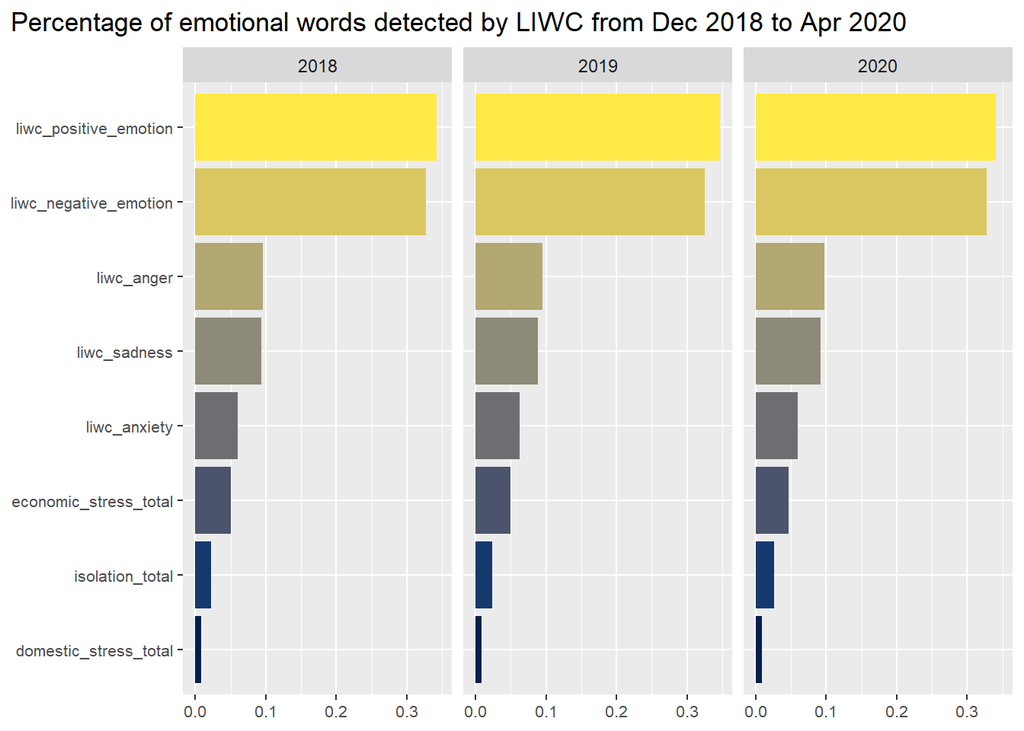

```r
red_mh |>
   group_by(year) |>
  summarize(
    isolation_total = sum(isolation_total),
    economic_stress_total = sum(economic_stress_total),
    domestic_stress_total = sum(domestic_stress_total),
    liwc_anger = sum(liwc_anger),
    liwc_anxiety = sum(liwc_anxiety),
    liwc_negative_emotion = sum(liwc_negative_emotion),
    liwc_positive_emotion = sum(liwc_positive_emotion),
    liwc_sadness = sum(liwc_sadness)
  ) |>
  rowwise() |>
  mutate(total_liwd = sum(c(isolation_total, economic_stress_total, domestic_stress_total,liwc_anger,liwc_anxiety, liwc_negative_emotion, liwc_positive_emotion, liwc_sadness))) |>
  pivot_longer(isolation_total:liwc_sadness,
               names_to = "emotion",
               values_to = "tot_emot_words") |>
  mutate(perc=(tot_emot_words/total_liwd)) |>
  mutate(emotion =fct_reorder(emotion,tot_emot_words)) |>
  ggplot(aes(y=emotion,
             x = perc,
             fill=emotion)) +
  geom_bar(stat = "identity",position = "dodge") +
  scale_fill_viridis(discrete = TRUE, option="cividis") +
  facet_wrap(~year, nrow = 1) +
  guides(fill = "none") +
  labs(title="Percentage of emotional words detected by LIWC from Dec 2018 to Apr 2020",
       # subtitle="subtitle",
       x=NULL,
       y=NULL
  ) +
  theme(
    plot.title.position = "plot",
    axis.text.x=element_text(size=8),
    axis.text.y=element_text(size=8)
  )
```

The graph below shows the percentage of same information of the graph above, but only for 2019 and 2020, from Jan. to Apr. of each year.

```r
# total of emotional words by emotions detected by liwc jan-apr 2019-2020 (TABLE AND plot)

red_mh |>
  filter(
    month == "01" | month == "02" | month == "03"  | month == "04",
    year == "2019" | year == "2020"
  ) |>
  group_by(year) |>
  summarize(
    isolation_total = sum(isolation_total),
    economic_stress_total = sum(economic_stress_total),
    domestic_stress_total = sum(domestic_stress_total),
    liwc_anger = sum(liwc_anger),
    liwc_anxiety = sum(liwc_anxiety),
    liwc_negative_emotion = sum(liwc_negative_emotion),
    liwc_positive_emotion = sum(liwc_positive_emotion),
    liwc_sadness = sum(liwc_sadness)
    ) |>
    pivot_longer(isolation_total:liwc_sadness,
                 names_to = "emotion",
                 values_to = "total_emot_words")
```

```
## # A tibble: 16 × 3
##    year  emotion               total_emot_words
##    <chr> <chr>                            <dbl>
##  1 2019  isolation_total                  38175
##  2 2019  economic_stress_total            88068
##  3 2019  domestic_stress_total            14481
##  4 2019  liwc_anger                      168889
##  5 2019  liwc_anxiety                    105859
##  6 2019  liwc_negative_emotion           575243
##  7 2019  liwc_positive_emotion           607264
##  8 2019  liwc_sadness                    163940
##  9 2020  isolation_total                  49095
## 10 2020  economic_stress_total            87259
## 11 2020  domestic_stress_total            15886
## 12 2020  liwc_anger                      180969
## 13 2020  liwc_anxiety                    109482
## 14 2020  liwc_negative_emotion           606397
## 15 2020  liwc_positive_emotion           629590
## 16 2020  liwc_sadness                    170445
```

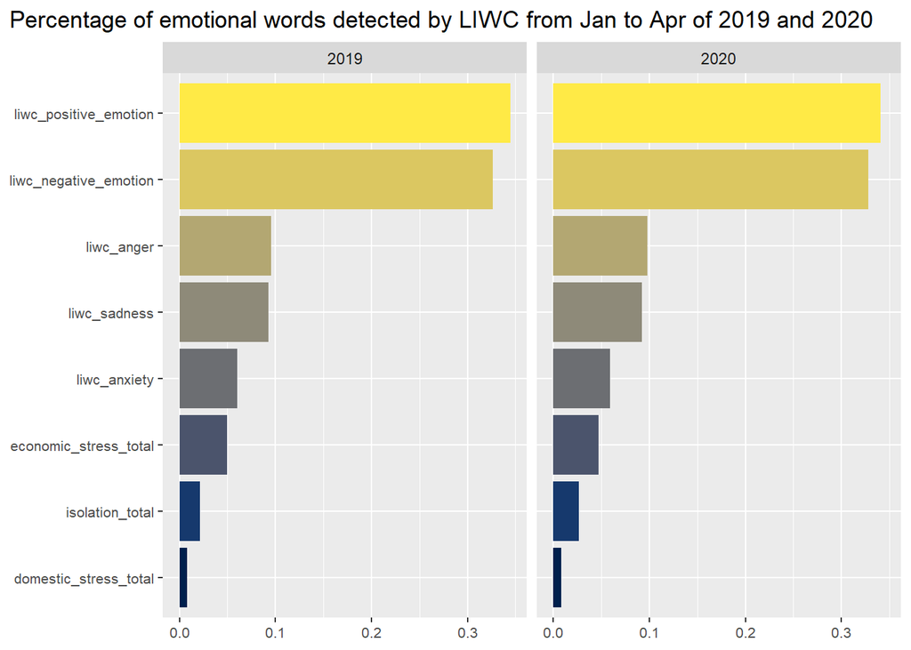

```r
options(scipen = 999)
red_mh |>
  filter(
    month == "01" | month == "02" | month == "03"  | month == "04",
    year == "2019" | year == "2020"
  ) |>
   group_by(year) |>
  summarize(
    isolation_total = sum(isolation_total),
    economic_stress_total = sum(economic_stress_total),
    domestic_stress_total = sum(domestic_stress_total),
    liwc_anger = sum(liwc_anger),
    liwc_anxiety = sum(liwc_anxiety),
    liwc_negative_emotion = sum(liwc_negative_emotion),
    liwc_positive_emotion = sum(liwc_positive_emotion),
    liwc_sadness = sum(liwc_sadness)
  ) |>
  rowwise() |>
  mutate(total_liwd = sum(c(isolation_total, economic_stress_total, domestic_stress_total,liwc_anger,liwc_anxiety, liwc_negative_emotion, liwc_positive_emotion, liwc_sadness))) |>
  pivot_longer(isolation_total:liwc_sadness,
               names_to = "emotion",
               values_to = "tot_emot_words") |>
  mutate(perc=(tot_emot_words/total_liwd)) |>
  mutate(emotion =fct_reorder(emotion,tot_emot_words)) |>
  ggplot(aes(y=emotion,
             x = perc,
             fill=emotion)) +
  geom_bar(stat = "identity",position = "dodge") +
  scale_fill_viridis(discrete = TRUE, option="cividis") +
  facet_wrap(~year, nrow = 1) +
  guides(fill = "none") +
  labs(title="Percentage of emotional words detected by LIWC from Jan to Apr of 2019 and 2020",
       # subtitle="subtitle",
       x=NULL,
       y=NULL
  ) +
  theme(
    plot.title.position = "plot",
    axis.text.x=element_text(size=8),
    axis.text.y=element_text(size=8)
  )
```

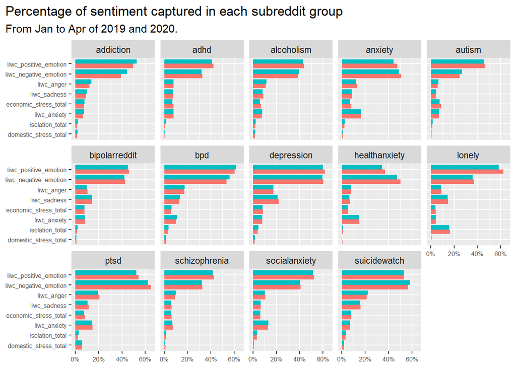

```r
# percentage of liwc per subreddit per year
options(scipen = 999)
red_mh |>
  filter(
    year!="2018",
    month=="01" | month=="02" | month=="03" | month=="04") |>
  group_by(subreddit, year) |>
  summarize(
    n_words = (mean(n_words) * 100),
    isolation_total = (mean(isolation_total) * 100),
    economic_stress_total = (mean(economic_stress_total) * 100),
    domestic_stress_total = (mean(domestic_stress_total) * 100),
    liwc_anger = (mean(liwc_anger) * 100),
    liwc_anxiety = (mean(liwc_anxiety) * 100),
    liwc_negative_emotion = (mean(liwc_negative_emotion) * 100),
    liwc_positive_emotion = (mean(liwc_positive_emotion) * 100),
    liwc_sadness = (mean(liwc_sadness) * 100)
  ) |>
  pivot_longer(isolation_total:liwc_sadness,
               names_to = "emotion",
               values_to = "perc_emotion") |>
  # summarise(a=n_words, b=)
  mutate(emotion =fct_reorder(emotion,perc_emotion)) |>
  ggplot(aes(y=emotion,
             x = perc_emotion,
             fill=year)) +
  geom_bar(stat = "identity",position = "dodge") +
  scale_x_continuous(labels = scales::percent_format(scale=.1)) +
  # scale_fill_viridis(discrete = TRUE, option="cividis") +
  facet_wrap(~subreddit, nrow = 3) +
  guides(fill = "none") +
  labs(title="Percentage of sentiment captured in each subreddit group",
       subtitle="From Jan to Apr of 2019 and 2020.",
       x=NULL,
       y=NULL
  ) +
  theme(
    plot.title.position = "plot",
     # panel.spacing = unit(1, "cm"),
    axis.text.x=element_text(size=6),
    axis.text.y=element_text(size=6)
  )
```

The table below informs us the average of number of words in each post, as well as the average of each sentiment in that post grouped by subreddit group and year.

```r
datatable(red_mh |>
  filter(year!="2018",
         month=="01" | month=="02" | month=="03" | month=="04"
  ) |>
  rowwise() |>
  mutate(total_w=sum(c(isolation_total, economic_stress_total, domestic_stress_total,liwc_anger,liwc_anxiety, liwc_negative_emotion, liwc_positive_emotion, liwc_sadness))) |>
  ungroup() |>
  group_by(subreddit, year) |>
  summarize(
    avg_num_words_post = (mean(n_words)),
    avg_sent_words_post = (mean(total_w))
  ))
```

|  | subreddit | year | avg_num_words_post | avg_sent_words_post |
| --- | --- | --- | --- | --- |
| 1 | addiction | 2019 | 195.282891022021 | 12.7735742518351 |
| 2 | addiction | 2020 | 207.34268087493 | 14.019068984857 |
| 3 | adhd | 2019 | 180.503687029419 | 10.8140184739579 |
| 4 | adhd | 2020 | 171.929936774004 | 10.5342596676959 |
| 5 | alcoholism | 2019 | 183.088213491475 | 12.0296515937732 |
| 6 | alcoholism | 2020 | 179.535714285714 | 11.9957983193277 |
| 7 | anxiety | 2019 | 183.86113452188 | 14.7546839546191 |
| 8 | anxiety | 2020 | 175.370093105184 | 14.0795797684952 |
| 9 | autism | 2019 | 162.180889115994 | 9.95145631067961 |
| 10 | autism | 2020 | 154.131733816206 | 10.1167949298325 |

[output cut: 18 more lines]

Based on the two graphs below, we see that there is an relationship between the number of emotional words found in a post and the lengths of it.

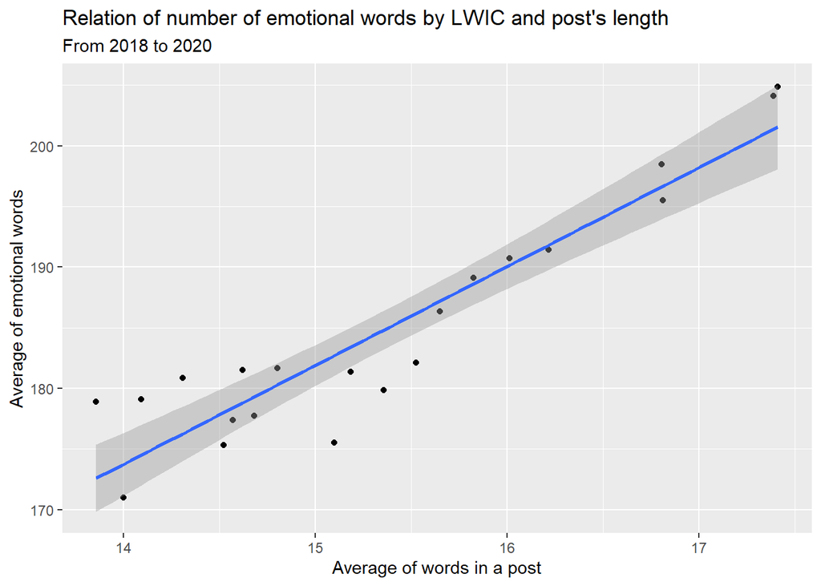

```r
df_2018<-red_mh |>
  filter(year=="2018") |>
  rowwise() |>
  mutate(total_w=sum(c(isolation_total, economic_stress_total, domestic_stress_total,liwc_anger,liwc_anxiety, liwc_negative_emotion, liwc_positive_emotion, liwc_sadness))) |>
  ungroup() |>
  group_by(month) |>
  summarize(
    n_words = (mean(n_words)),
    sent_w = (mean(total_w))
  )

df_2019<-red_mh |>
  filter(year=="2019") |>
  rowwise() |>
  mutate(total_w=sum(c(isolation_total, economic_stress_total, domestic_stress_total,liwc_anger,liwc_anxiety, liwc_negative_emotion, liwc_positive_emotion, liwc_sadness))) |>
  ungroup() |>
  group_by(month) |>
  summarize(
    n_words = (mean(n_words)),
    sent_w = (mean(total_w))
  )

df_2020<-red_mh |>
  filter(year=="2020") |>
  rowwise() |>
  mutate(total_w=sum(c(isolation_total, economic_stress_total, domestic_stress_total,liwc_anger,liwc_anxiety, liwc_negative_emotion, liwc_positive_emotion, liwc_sadness))) |>
  ungroup() |>
  group_by(month) |>
  summarize(
    n_words = (mean(n_words)),
    sent_w = (mean(total_w))
  )

data <- rbind(df_2018, df_2019, df_2020)

   ggplot(data, aes(x = sent_w,y=n_words)) +
  geom_point() +
     geom_smooth(method="lm") +
     labs(title="Relation of number of emotional words by LWIC and post's length",
       subtitle="From 2018 to 2020",
       x="Average of words in a post",
       y="Average of emotional words"
  ) +
   scale_y_continuous(labels = scales::label_number_si())
```

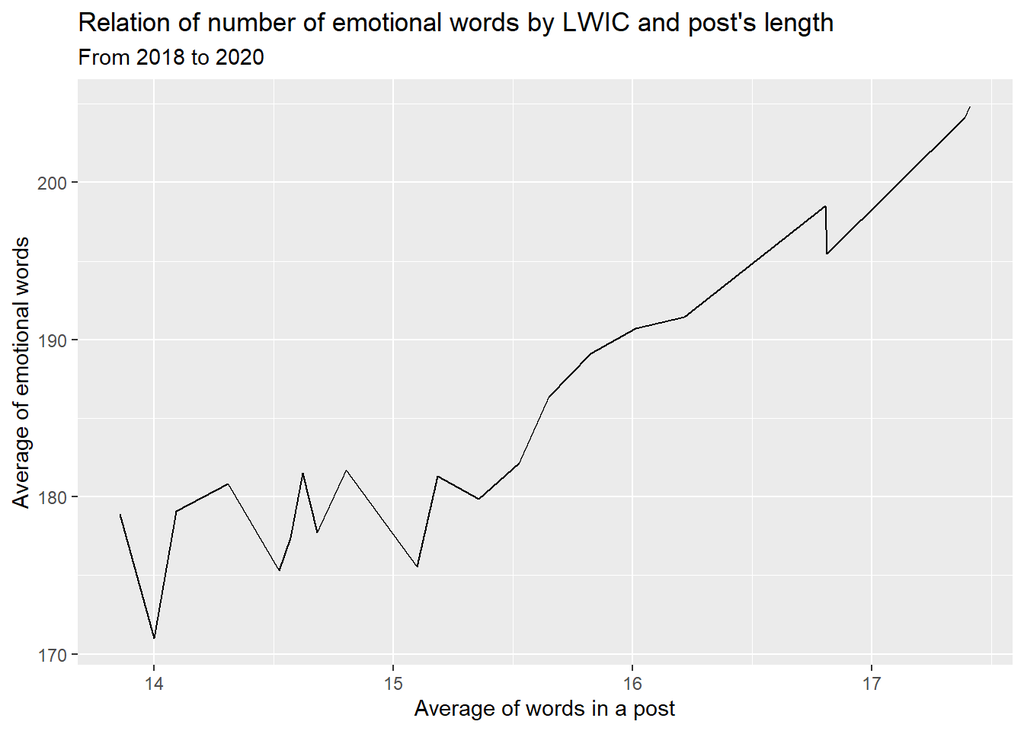

```r
  ggplot(data, aes(x = sent_w,y=n_words)) +
    geom_line() +
     labs(title="Relation of number of emotional words by LWIC and post's length",
       subtitle="From 2018 to 2020",
       x="Average of words in a post",
       y="Average of emotional words"
  ) +
   scale_y_continuous(labels = scales::label_number_si())
```

## Data Analysis

### Question 1

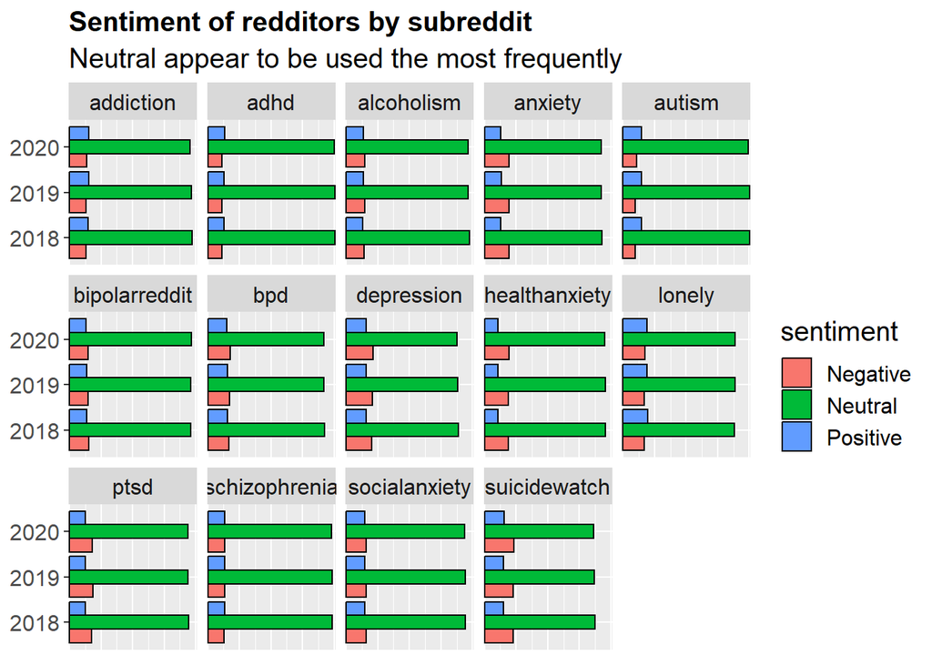

```r
red_mh |>
  group_by(subreddit, year) |>
  summarize(Negative = (mean(sent_neg) * 100),
            Neutral = (mean(sent_neu) * 100),
            Positive = (mean(sent_pos) * 100)) |>
  pivot_longer(cols = -subreddit & -year,
               names_to = "sentiment",
               values_to = "Percentage of subredditors") |>
  ggplot(aes(x = year, y= `Percentage of subredditors` , fill = (sentiment))) +
  geom_bar(stat = "identity",
           position = "dodge",
           color = "black") +
  scale_y_continuous(expand = c(0, .3)) +
  coord_flip() +
  facet_wrap(~ subreddit, nrow=3) +
  guides(fill = guide_legend("sentiment")) +
  labs(title = "Sentiment of redditors by subreddit",
       subtitle = "Neutral appear to be used the most frequently") + theme(text = element_text(size = 15)) +
  theme(
    plot.title = element_text(size = 15, face = "bold"),
    axis.title.x = element_blank(),

    axis.text.x = element_blank(),
    axis.ticks.x=element_blank(),
    axis.title.y = element_blank()
    )
```

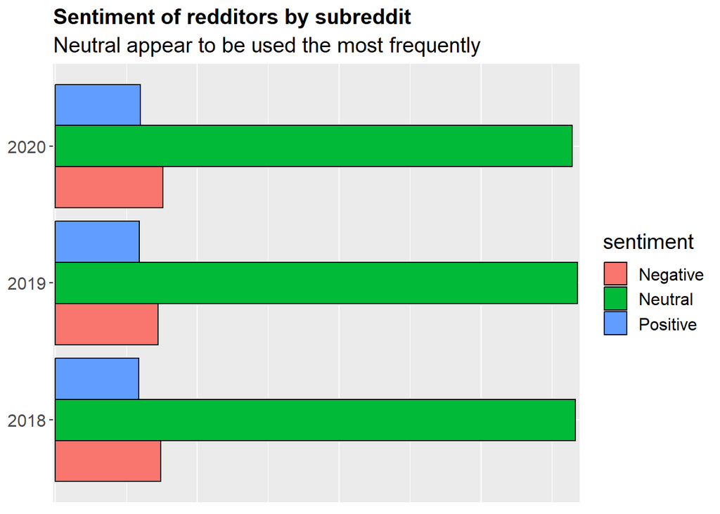

```r
red_mh |>
  group_by(year) |>
  summarize(Negative = (mean(sent_neg) * 100),
            Neutral = (mean(sent_neu) * 100),
            Positive = (mean(sent_pos) * 100)) |>
  pivot_longer(cols = -year,
               names_to = "sentiment",
               values_to = "Percentage of subredditors") |>
  ggplot(aes(x = year, y= `Percentage of subredditors` , fill = sentiment)) +
  geom_bar(stat = "identity",
           position = "dodge",
           color = "black") +
  scale_y_continuous(expand = c(0, .3)) +
  coord_flip() +
  guides(fill = guide_legend("sentiment")) +
  labs(title = "Sentiment of redditors by subreddit",
       subtitle = "Neutral appear to be used the most frequently") + theme(text = element_text(size = 15)) +
  theme(
    plot.title = element_text(size = 15, face = "bold"),
    axis.title.x = element_blank(),

    axis.text.x = element_blank(),
    axis.ticks.x=element_blank(),
    axis.title.y = element_blank()
    )
```

Seen how a ‘negative’ sentiment is common across the subreddits after neutral we want to see other variables and see if there are some patterns like more economic stress can be a factor of this. As seen from the bar plot the economic stress throughout the pandemic decreased slightly. In 2018 the economic stress is high as the average is > 80 % and in 2019 this drops to < 80 % and drops further in 2020. Nonetheless, this is still the highest compared to domestic and isolation.

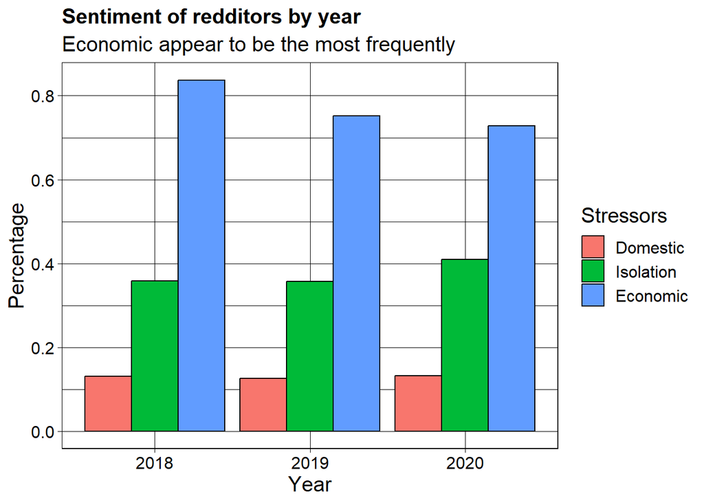

```r
red_mh |>
  group_by(year) |>
  summarize(Isolation = mean(isolation_total),
            Economic = mean(economic_stress_total),
            Domestic = mean(domestic_stress_total)) |>
  pivot_longer(cols = -year,
               names_to = "Type",
               values_to = "Percentage") |>
  rename(Year = year) |>
  ggplot(aes(y = Percentage,
             x = Year,
             fill = reorder(Type, Percentage))) +
  geom_bar(stat = "identity",
           position = "dodge",
           color = "black") +
  theme_linedraw() +
  guides(fill = guide_legend("Stressors")) +
  labs(title = "Sentiment of redditors by year",
       subtitle = "Economic appear to be the most frequently") + theme(text = element_text(size = 15)) +
  theme(
    plot.title = element_text(size = 15, face = "bold"))
```

### Question 2

In order to explore the relationship between substance abuse community data and the WHO’s inference that these communities be driven online. If this inference were to be true, we should see that regardless of sentiment, there should in theory be more and longer posts to the substance abuse communities. This would represent an increases in community engagement. Because there are gaps in the data, we will be limiting the exploration the time period of January to April for both 2019 and 2020. This represents the very beginnings of the Pandemic Lockdowns where we would expect to see changes.

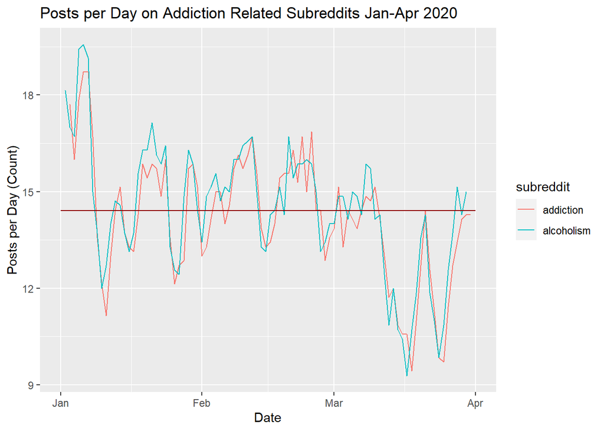

```r
#Unify the date object to make analysis easier.
red_mh$Date <- as.Date(with(red_mh, paste(year, month, day,sep="-")), "%Y-%m-%d")

#Filter the data for the addiction related subreddits
post_data <- red_mh[red_mh$subreddit %in% c('addiction','alcoholism'),] |>
  drop_na(Date)

#Identify the time window
post_data2020 <- post_data[(post_data$Date >= as.Date("2020-01-01")) & (post_data$Date <= as.Date("2020-04-01")),]
post_data2019 <- post_data[(post_data$Date >= as.Date("2019-01-01")) & (post_data$Date <= as.Date("2019-04-01")),]

#Generate a chart of the Date and subreddit data charting the amount of posts per dat
post_data2020 |>
  group_by(Date, subreddit) %>%
  summarise(total_count=n(),.groups = 'drop') |>
  ggplot(aes(x=Date, y=total_count, group=subreddit, color=subreddit)) +
  geom_line(aes(y=rollmean(total_count, 7, na.pad=TRUE))) +
  geom_line(aes(y = mean(total_count)), color="darkred") +
  #geom_hline(yintercept = mean(total_count), color="blue") +
  xlab("Date") +
  ylab("Posts per Day (Count)") +
  labs(title = "Posts per Day on Addiction Related Subreddits Jan-Apr 2020")
```

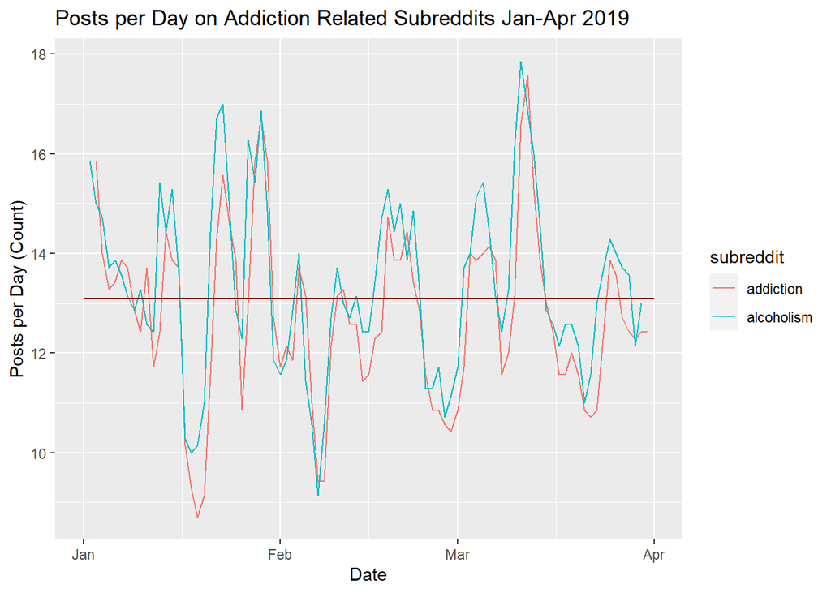

```r
post_data2019 |>
  group_by(Date, subreddit) %>%
  summarise(total_count=n(),.groups = 'drop') |>
  ggplot(aes(x=Date, y=total_count, group=subreddit, color=subreddit)) +
  geom_line(aes(y=rollmean(total_count, 7, na.pad=TRUE))) +
  geom_line(aes(y = mean(total_count)), color="darkred") +
  #geom_hline(yintercept = mean(total_count), color="red") +
  xlab("Date") +
  ylab("Posts per Day (Count)") +
  labs(title = "Posts per Day on Addiction Related Subreddits Jan-Apr 2019")
```

Given the charts above, we see that there was increased usage of the addiction and alcoholism communities. We saw on average ~1 post more than in the same period than the year before. In order to gauge engagement we should next check to see if the post length changed. Shorter but more frequent posts may indicate that post-frequency may indicate spam or or other artificial growth of the data. Plotting the data

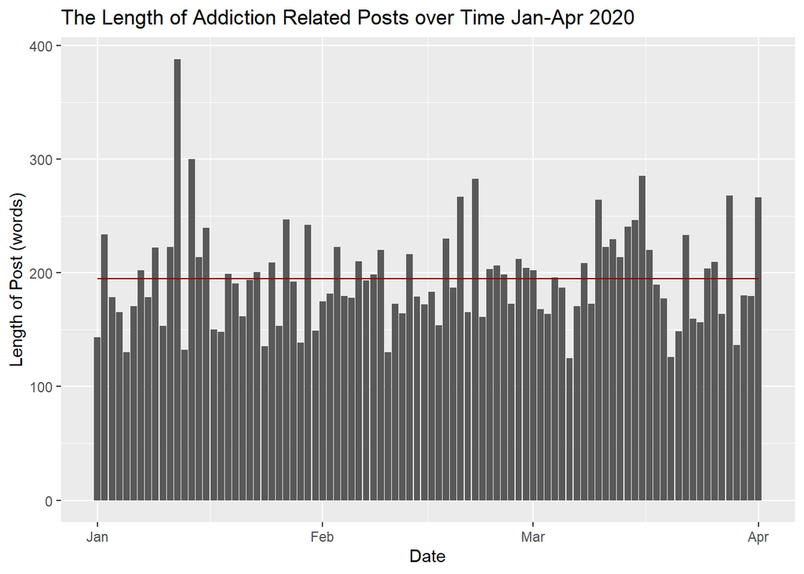

```r
post_data2020 |>
  group_by(Date) |>
  summarise(mean_count = mean(n_words)) |>
  ggplot(aes(x = Date, y = mean_count)) +
  geom_col(position = 'dodge') +
  geom_line(aes(y = mean(mean_count)), color="darkred") +

  #Fix up the format so that it is legible
  xlab("Date") +
  ylab("Length of Post (words)") +
  labs(title = "The Length of Addiction Related Posts over Time Jan-Apr 2020")
```